# Plotting Multiple Sequence Alignment Chord Diagrams with ‘ggchord’

DangJem

2025-07-13

## 1. Introduction

`ggchord` is a ggplot2-based R package for plotting multiple sequence alignment chord diagrams, supporting visualization of alignment relationships between sequences and gene annotation information. This tutorial demonstrates its core functions and parameter usage through examples.

## 2. Installation and Loading

First, install and load the `ggchord` package (if not yet published on CRAN, install from local or GitHub):

```r
# Install from local
devtools::install_local("path/to/ggchord_0.2.0.tar.gz")

# Load the package
library(ggchord)
library(dplyr)  # For data processing
```

## 3. Data Preparation

`ggchord` requires three types of data (sequence data is mandatory):  
- Sequence data (`seq_data`): Contains sequence IDs and lengths  
- Alignment data (`ribbon_data`): BLAST alignment results for drawing inter-sequence ribbons  
- Gene annotation data (`gene_data`): Contains gene positions and annotation information

This tutorial uses built-in example data (added via `usethis::use_data()`):

```r
# Load built-in example data
data(seq_data_example)    # Sequence data
data(ribbon_data_example) # BLAST alignment data
data(gene_data_example)   # Gene annotation data (short genes filtered out)

# Inspect data structure
head(seq_data_example)
```

```
##       seq_id length
## 1 MT108731.1  64323
## 2 MT118296.1  32090
## 3 OQ646790.1  57367
## 4 OR222515.1  83080
```

```r
head(ribbon_data_example)
```

```
##      qaccver    saccver pident length mismatches gapopen qstart  qend sstart
## 1 MT108731.1 MT118296.1 98.612  24856        314      25  26298 51139   7121
## 2 MT108731.1 MT118296.1 97.031   4412        125       5  21513 25922   2365
## 3 MT108731.1 MT118296.1 94.181    464         19       3  20691 21146   1032
## 4 MT108731.1 MT118296.1 96.689    302         10       0  20376 20677    403
## 5 MT108731.1 MT118296.1 91.736    121         10       0  19726 19846      5
## 6 MT108731.1 MT118296.1 89.344    122          9       2  19759 19877    710
##    send    evalue bitscore qcovs  qlen  slen sstrand stitle
## 1 31959  0.00e+00    43960    47 64323 32090    plus    N/A
## 2  6772  0.00e+00     7417    47 64323 32090    plus    N/A
## 3  1495  0.00e+00      701    47 64323 32090    plus    N/A
## 4   704 5.93e-143      503    47 64323 32090    plus    N/A
## 5   125  2.46e-42      169    47 64323 32090    plus    N/A
## 6   830  8.90e-37      150    47 64323 32090    plus    N/A
```

```r
head(gene_data_example)
```

```
##       seq_id start   end strand                 anno
## 1 MT108731.1 60709 63087      + hypothetical protein
## 2 MT108731.1 57550 59490      + hypothetical protein
## 3 MT108731.1 49101 50831      + hypothetical protein
## 4 MT108731.1 13064 14554      + hypothetical protein
## 5 MT108731.1 48053 49111      + hypothetical protein
## 6 MT118296.1  9575 12046      + hypothetical protein
```

## 4. Basic Usage

### 4.1 Using Only Sequence Data

Sequence data is fundamental for drawing chord diagrams, requiring at minimum `seq_id` (sequence ID) and `length` (sequence length):

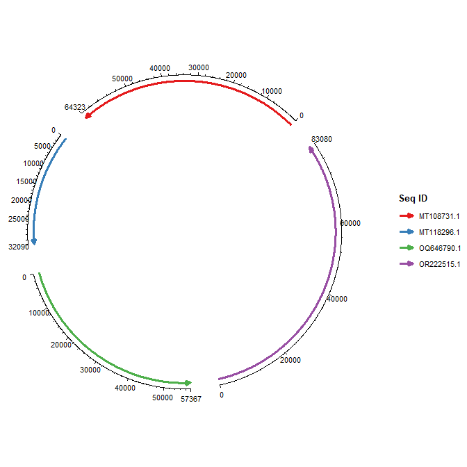

```r
# Basic chord diagram: sequences only
p1 <- ggchord(
  seq_data = seq_data_example
)
print(p1)
```

#### Adjusting Sequence Parameters

Customize sequence order, orientation, curvature, and colors via parameters:

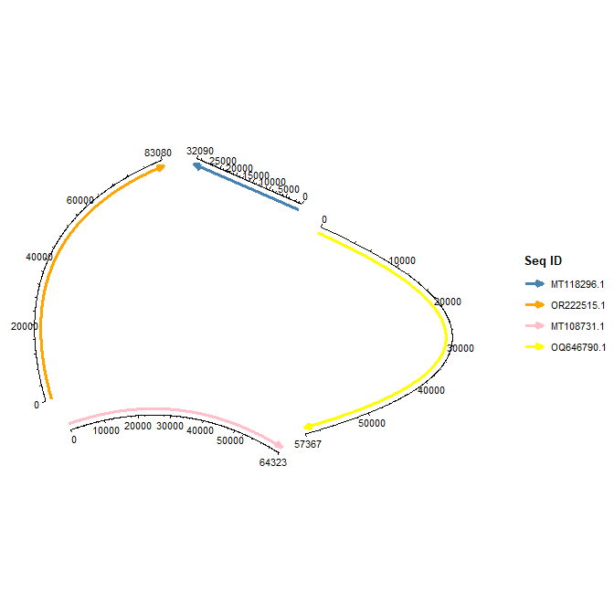

```r
p2 <- ggchord(
  seq_data = seq_data_example,
  seq_order = c("MT118296.1", "OR222515.1", "MT108731.1", "OQ646790.1"),  # Sequence order
  seq_orientation = c(1, -1, 1, -1),  # Direction (1 = forward, -1 = reverse)
  seq_curvature = c(0, 2, -2, 6),     # Curvature (0 = straight line, 1 = standard arc)
  seq_colors = c("steelblue", "orange", "pink", "yellow")  # Sequence colors
)
print(p2)
```

### 4.2 Adding Sequence Alignment Data

Alignment data (`ribbon_data`) visualizes sequence similarity, with colors defaulting to identity (`pident`):

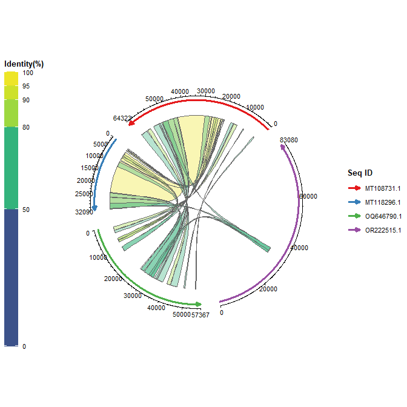

```r
# Show sequence alignment relationships
p3 <- ggchord(
  seq_data = seq_data_example,
  ribbon_data = ribbon_data_example
)
print(p3)
```

#### Customizing Ribbon Colors

Adjust ribbon color schemes via `ribbon_color_scheme`:

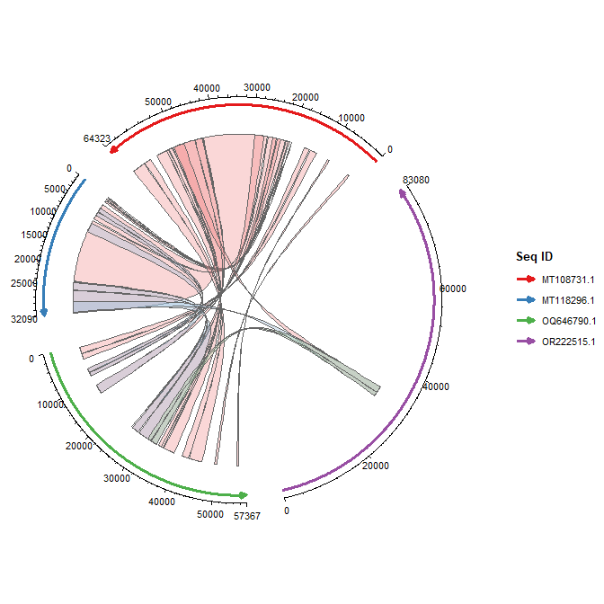

```r
# Color by query sequence
p4 <- ggchord(
  seq_data = seq_data_example,
  ribbon_data = ribbon_data_example,
  ribbon_color_scheme = "query"  # Ribbon color matches query sequence
)
print(p4)
```

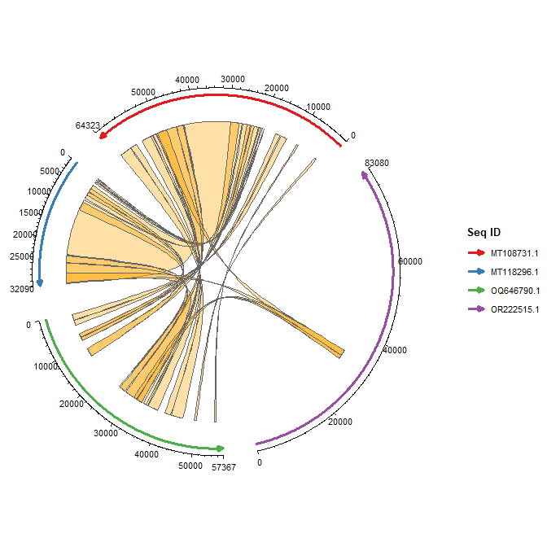

```r
# Single color
p5 <- ggchord(
  seq_data = seq_data_example,
  ribbon_data = ribbon_data_example,
  ribbon_color_scheme = "single",  # Uniform color
  ribbon_colors = "orange"         # Custom color
)
print(p5)
```

#### Impact of Sequence Layout on Ribbons

Ribbons automatically adapt to sequence orientation, curvature, and spacing:

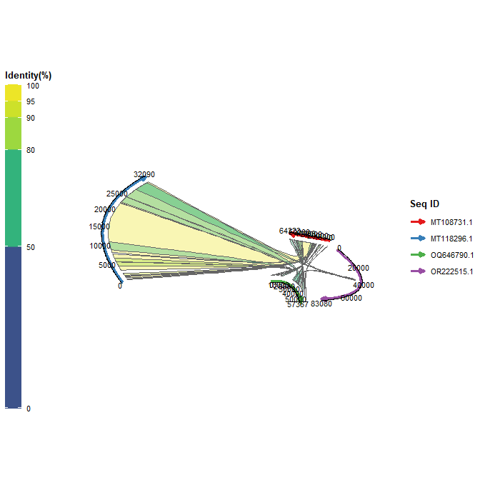

```r
p6 <- ggchord(
  seq_data = seq_data_example,
  ribbon_data = ribbon_data_example,
  seq_orientation = c(1, -1, 1, -1),  # Sequence orientation
  seq_curvature = c(0, 2, -2, 6),     # Curvature
  seq_gap = c(0.1, 0.05, 0.09, 0.05), # Inter-sequence gaps
  seq_radius = c(1, 5, 1, 1)          # Sequence radii
)
print(p6)
```

### 4.3 Adding Gene Annotation Information

Gene annotation data (`gene_data`) marks gene positions on sequences, with colors defaulting to strand direction (`strand`):

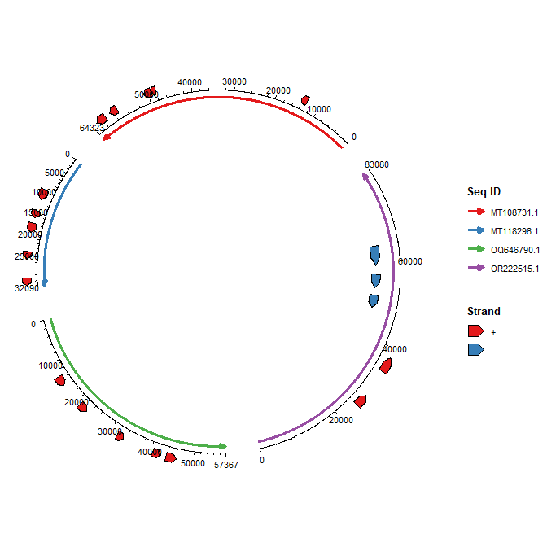

```r
# Show gene annotations
p7 <- ggchord(
  seq_data = seq_data_example,
  gene_data = gene_data_example
)
print(p7)
```

#### Customizing Gene Arrow Styles

Adjust gene colors via `gene_color_scheme` or display gene labels:

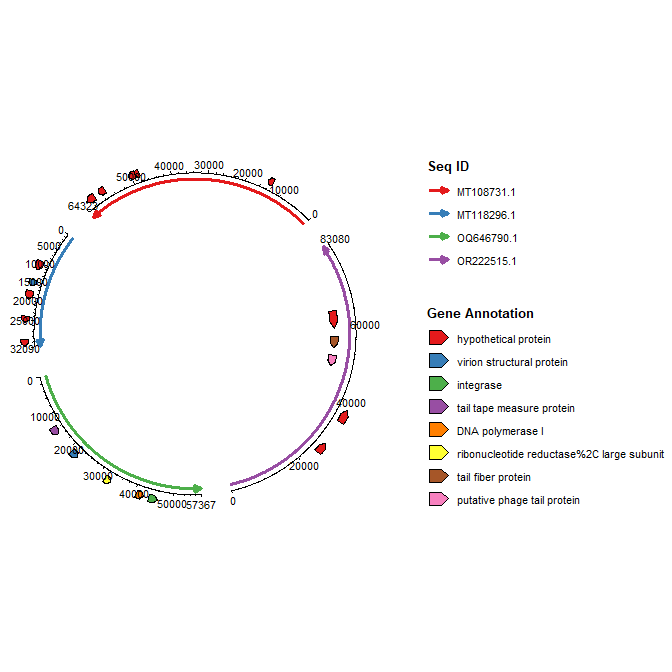

```r
# Color by gene annotation category
p8 <- ggchord(
  seq_data = seq_data_example,
  gene_data = gene_data_example,
  gene_color_scheme = "manual"  # Color by gene annotation (anno)
)
print(p8)
```

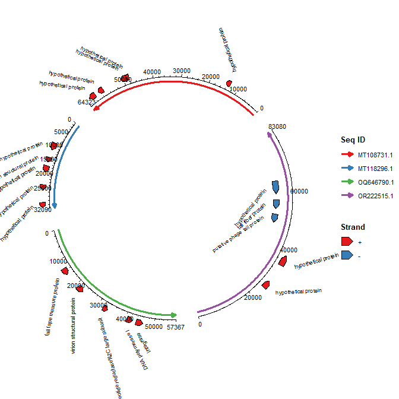

```r
# Display gene labels and adjust styles
p9 <- ggchord(
  seq_data = seq_data_example,
  gene_data = gene_data_example,
  gene_label_show = TRUE,        # Show labels
  gene_label_rotation = 45,      # Label rotation angle
  gene_label_radial_offset = 0.1, # Radial offset of labels
  panel_margin = list(l = 0.2)    # Left margin
)
print(p9)
```

## 5. Comprehensive Example

Using sequence, alignment, and gene data simultaneously with fine parameter adjustments:

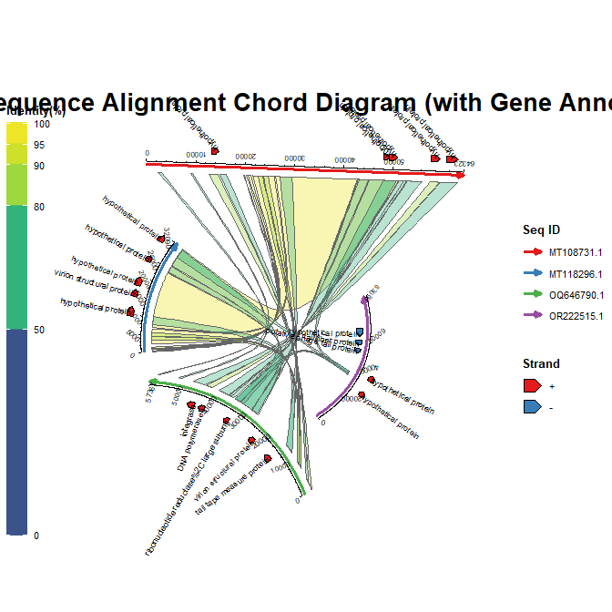

```r
p10 <- ggchord(
  seq_data = seq_data_example,
  ribbon_data = ribbon_data_example,
  gene_data = gene_data_example,
  title = "Multiple Sequence Alignment Chord Diagram (with Gene Annotations)",  # Title

  # Sequence parameters
  seq_gap = 0.03,
  seq_radius = c(3, 2, 2, 1),
  seq_orientation = c(-1, -1, -1, 1),
  seq_curvature = c(0, 1, -1, 1.5),

  # Gene parameters
  gene_offset = list(             # Gene arrow offset (strand-specific)
    c("+" = 0.2, "-" = -0.2),
    c("+" = 0.2, "-" = -0.2),
    c("+" = 0.2, "-" = 0),
    c("+" = 0.2, "-" = 0.1)
  ),
  gene_label_rotation = list(     # Gene label rotation (strand-specific)
    c("+" = 45, "-" = -45),
    c("+" = 0.2, "-" = -0.2),
    c("+" = 0.2, "-" = 0),
    c("+" = 0.2, "-" = 0.1)
  ),
  gene_width = 0.08,              # Gene arrow width
  gene_label_show = TRUE,         # Show gene labels

  # Ribbon parameters
  ribbon_gap = 0.1,
  ribbon_color_scheme = "pident", # Color by identity

  # Axis parameters
  axis_label_orientation = c(0, 45, 80, 130), # Tick label angles
  axis_tick_major_length = 0.03,
  axis_label_size = 2,

  # Overall style
  rotation = 45,  # Plot rotation angle
  show_axis = TRUE,
  panel_margin = list(t = 0.1)
)
print(p10)
```

## 6. Notes

- `ggchord` is currently in early development; some parameter combinations may cause graphical distortions, which will be optimized in future versions.
- Display effects of gene labels and ribbons may require multiple parameter adjustments for optimal results.
- For more parameter details, refer to the function documentation: `?ggchord`.